# Exploratory Data Analysis

STOR 320.02 Group 9

February 03, 2025

# Creator: Riley Modlin

### Q1: Is there a relationship between winners’/losers’ handedness and the number of aces they have per match in the ATP?

This could be useful to determine if using a specific hand provides a competitive advantage in tennis. Players could use this information to determine if training with a certain hand would help their performance.

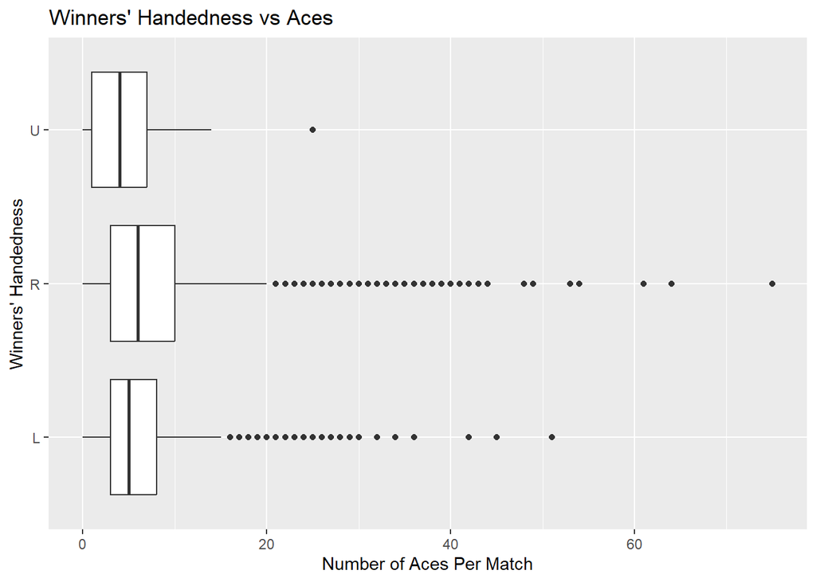

```r
ggplot(data = ATP %>% filter(!is.na(winner_hand)), mapping = aes(x = w_ace, y = winner_hand)) +
         geom_boxplot() +xlab("Number of Aces Per Match")+ylab("Winners' Handedness")+ggtitle("Winners' Handedness vs Aces")
```

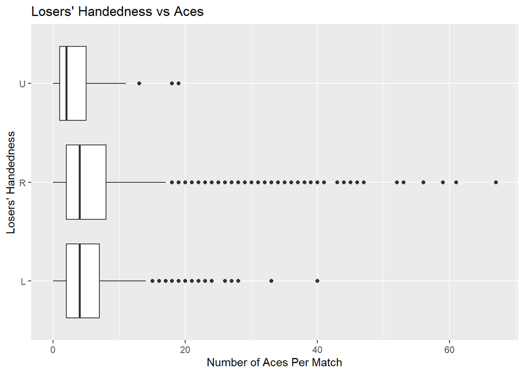

```r
ggplot(data = ATP %>% filter(!is.na(loser_hand)), mapping = aes(x = l_ace, y = loser_hand)) +
        geom_boxplot() + xlab("Number of Aces Per Match")+ylab("Losers' Handedness")+ggtitle("Losers' Handedness vs Aces")
```

### Q2: How does match minutes vary between the ATP & the WTA?

Comparing match minutes in the ATP & WTA can help determine the amount of stamina or training required to perform well for the amount of time required to play a match.

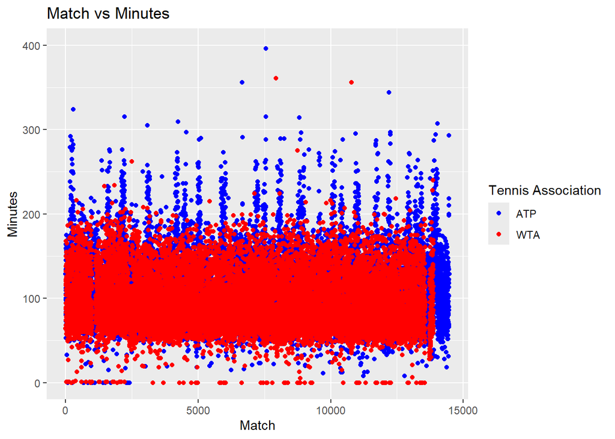

```r
library(knitr)
ggplot() +
  geom_point(data = ATP, mapping = aes(x=...1, y=minutes, color = "ATP")) +
  geom_point(data = WTA, mapping = aes(x=...1, y=minutes, color ="WTA")) +
  xlab("Match")+ylab("Minutes")+ggtitle("Match vs Minutes") +
  scale_color_manual(values=c("Blue","Red")) +
  guides(color=guide_legend(title="Tennis Association")) +
  ylim(0,400)
```

```r
ATP %>% summarize(ATP_Average_Minutes = mean(na.omit(ATP$minutes)), ATP_Minutes_Variance = var(na.omit(ATP$minutes))) %>% kable()
```

| ATP_Average_Minutes | ATP_Minutes_Variance |
| --- | --- |
| 111.1085 | 1890.672 |

```r
WTA %>% summarize(WTA_Average_Minutes = mean(na.omit(WTA$minutes)), WTA_Minutes_Variance = var(na.omit(WTA$minutes))) %>% kable()
```

| WTA_Average_Minutes | WTA_Minutes_Variance |
| --- | --- |
| 97.2548 | 1747.377 |

# Interpreter: Zhuocheng Han

### Q1: How does match statistics differ by surface type?

The box plots offer a comparative view of match statistics across tennis surfaces, revealing general uniformity with minor variations for most variables. This suggests that player performance and match conditions may have a more pronounced influence than surface type on these metrics.

An exception is found in the “ace” count, which significantly increases on grass courts. This can be ascribed to the unique properties of grass—specifically, its lower friction and the resultant higher ball velocity—which naturally promote a greater number of nonreturnable serves.

[figure not shown]

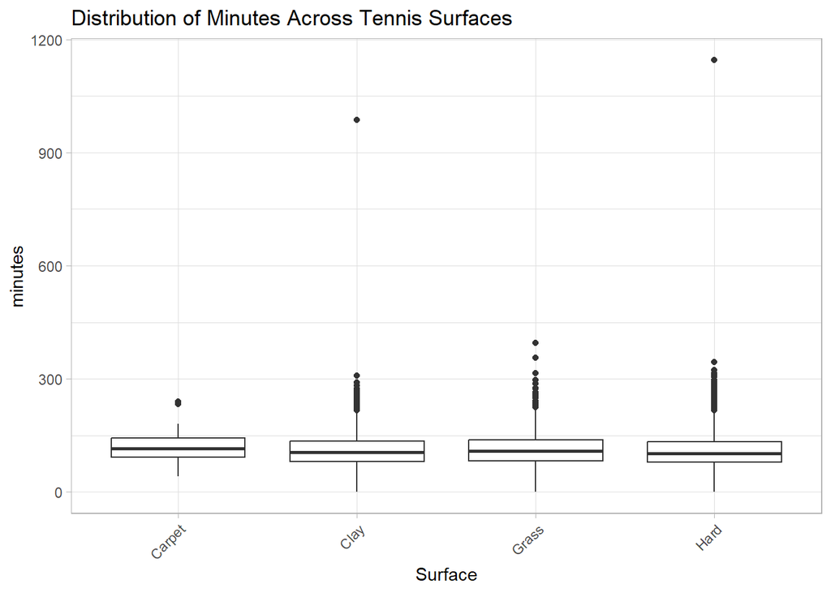

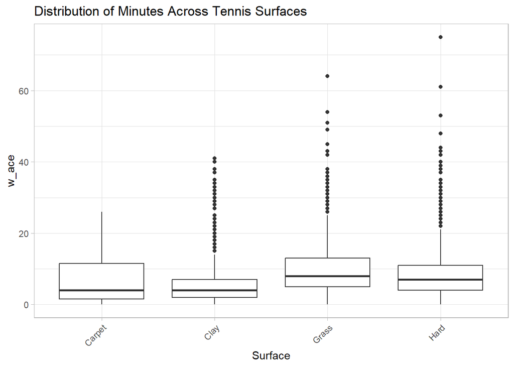

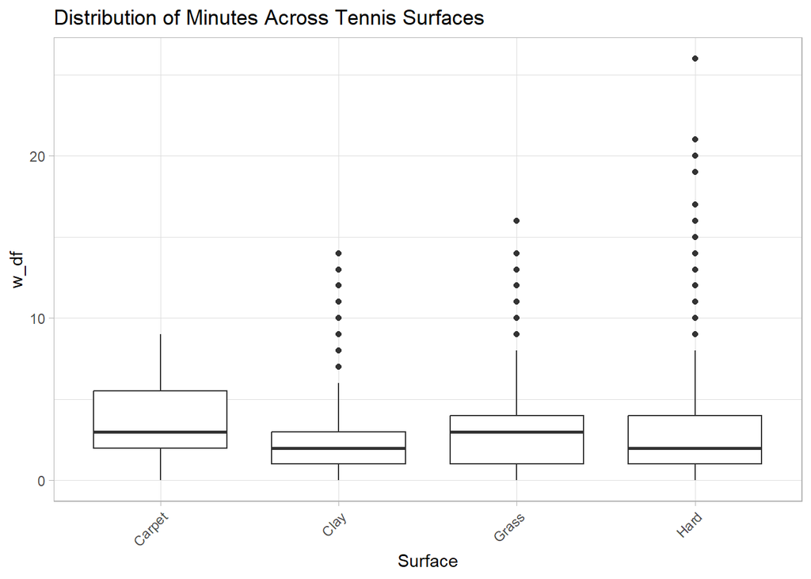

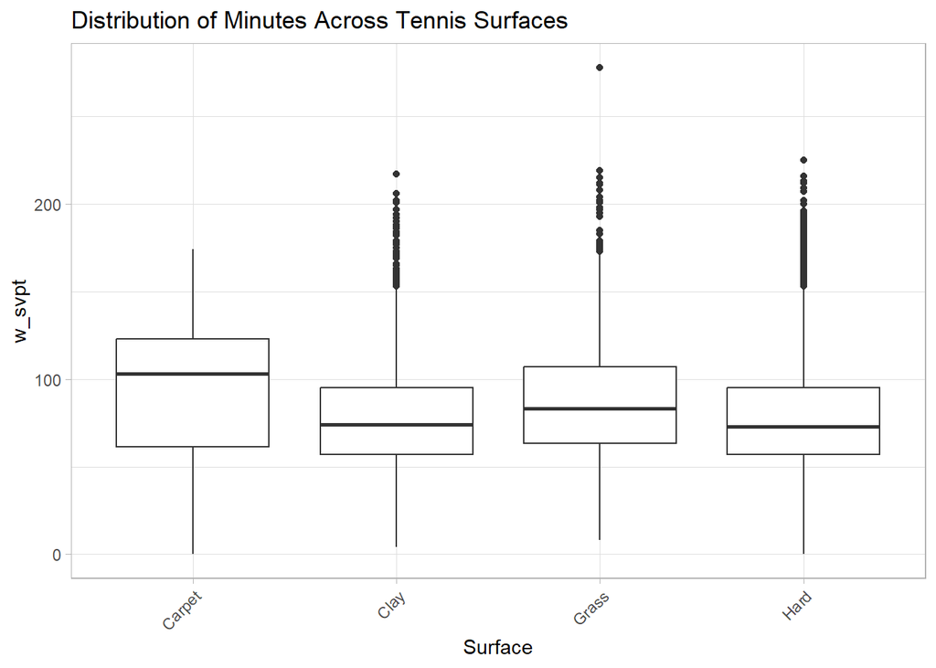

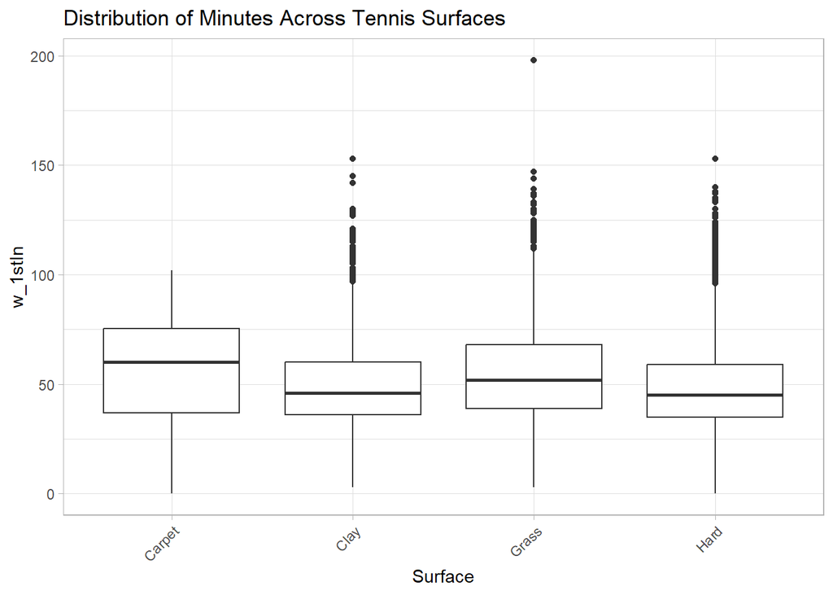

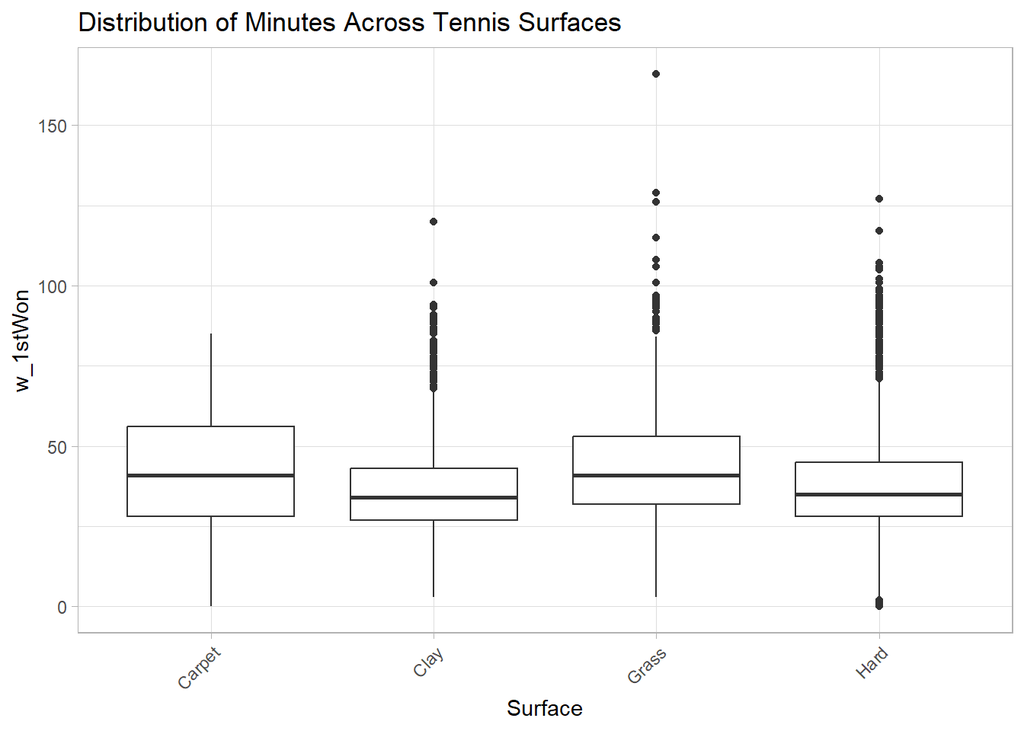

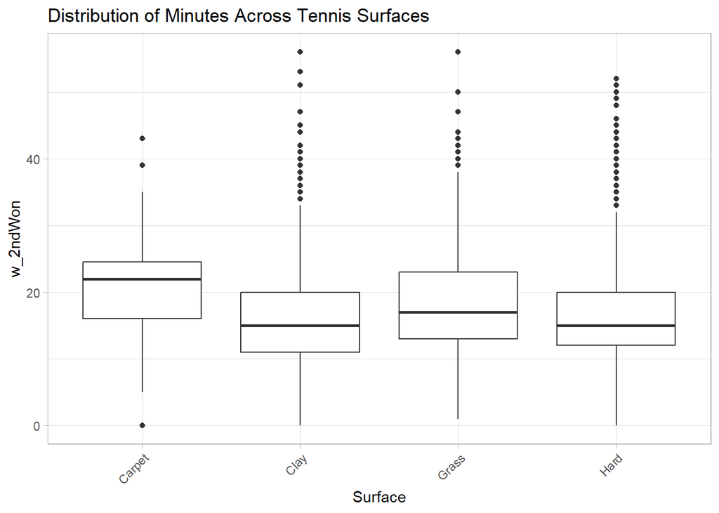

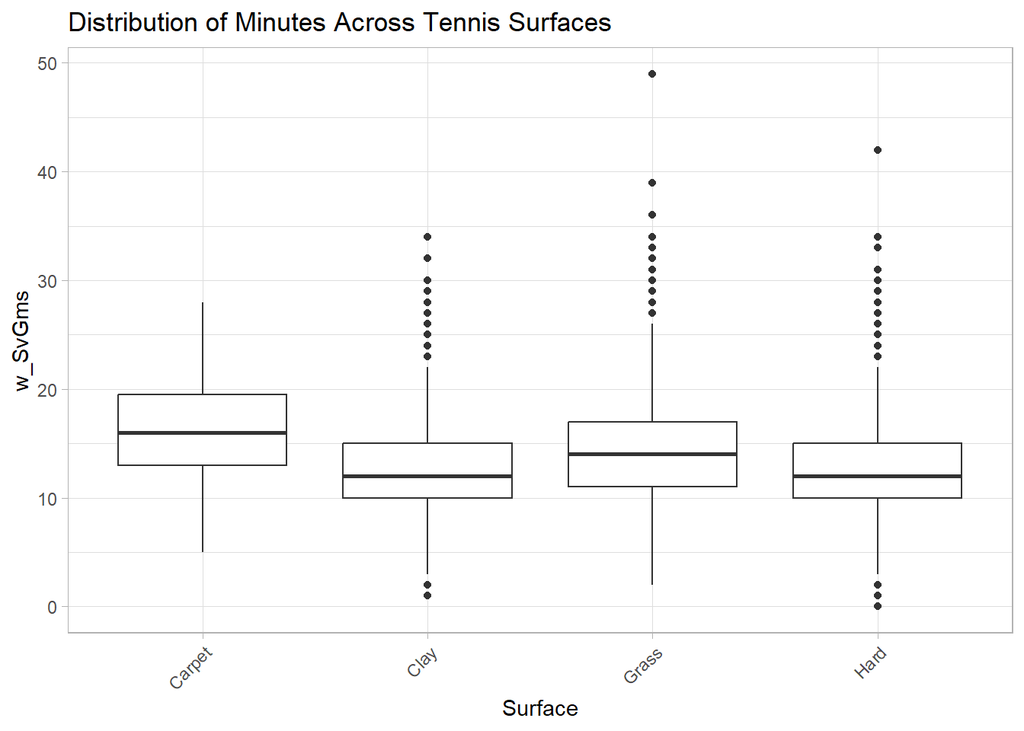

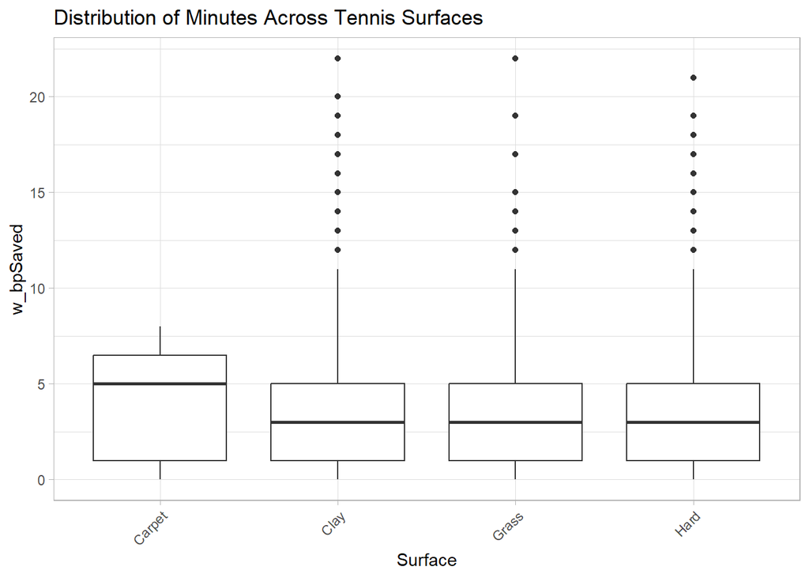

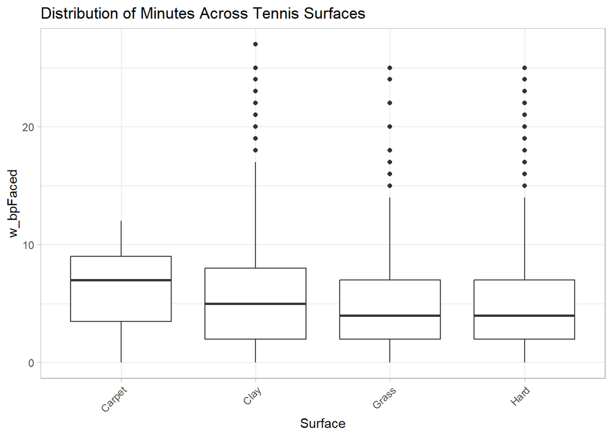

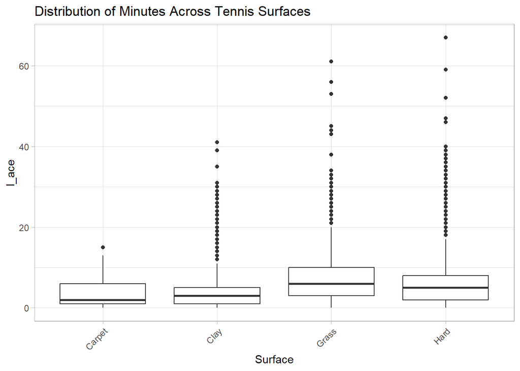

[8 more figures not shown]

```r
atp<-ATP[!ATP$surface=="carpet",]
atp_new <- atp[, c("surface", "minutes", "w_ace", "w_df", "w_svpt", "w_1stIn", "w_1stWon", "w_2ndWon", "w_SvGms", "w_bpSaved", "w_bpFaced",
                        "l_ace", "l_df", "l_svpt", "l_1stIn", "l_1stWon", "l_2ndWon", "l_SvGms", "l_bpSaved", "l_bpFaced")]

var<- c("surface", "minutes", "w_ace", "w_df", "w_svpt", "w_1stIn", "w_1stWon", "w_2ndWon", "w_SvGms", "w_bpSaved", "w_bpFaced",
                        "l_ace", "l_df", "l_svpt", "l_1stIn", "l_1stWon", "l_2ndWon", "l_SvGms", "l_bpSaved", "l_bpFaced")

for (i in 1:length(var)){
  p <- ggplot(atp_new, aes_string(x = "surface", y = var[i])) +
    geom_boxplot() +
    labs(title = "Distribution of Minutes Across Tennis Surfaces", y = var[i], x = "Surface") +
    theme_light() +
    theme(axis.text.x = element_text(angle = 45, hjust = 1))
  print(p)
}
```

### Q2: How does the number of aces influence the match duration?

Match duration shapes tennis strategy, influencing training for endurance, tactical approaches for different surfaces, and equipment choices for comfort. Players also plan nutrition and hydration for sustained energy, mental training for focus, and recovery protocols to handle the physical demands of long matches. The preliminary hypothesis posited a negative correlation between the number of aces served and match duration, under the assumption that aces, as expedient conclusions to points, would abbreviate the length of a match. Contrary to this expectation, the analysis of the data across various surface types reveals a positive correlation between the total number of aces and the duration of the match. This observation is statistically plausible as a longer match duration inherently provides more serving opportunities, thereby increasing the potential for aces. However, for the same number of aces, the duration of the match exhibits considerable variability, indicating that other factors such as break points faced and break points saved and number of games served also significantly influence match length. The presence of aces alone does not dictate the temporal extent of the game; rather, it is the interplay of multiple game dynamics that collectively determine the duration. Further statistical modeling, including regression analysis controlling for these additional variables, would provide a more nuanced understanding of the factors that most impact match duration.

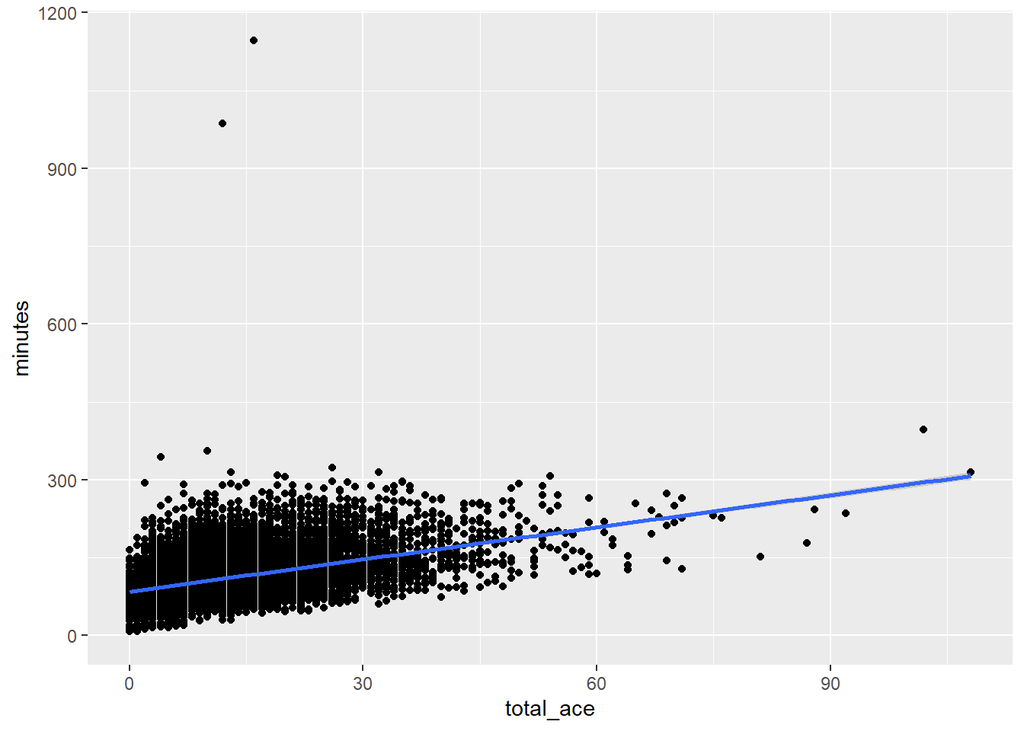

```r
atp$total_ace <- atp$w_ace + atp_new$l_ace
atp<-atp[!atp$surface=="carpet",]

ggplot(atp, aes(x=total_ace, y = minutes))+
  geom_point()+
  geom_smooth(method = 'lm')
```

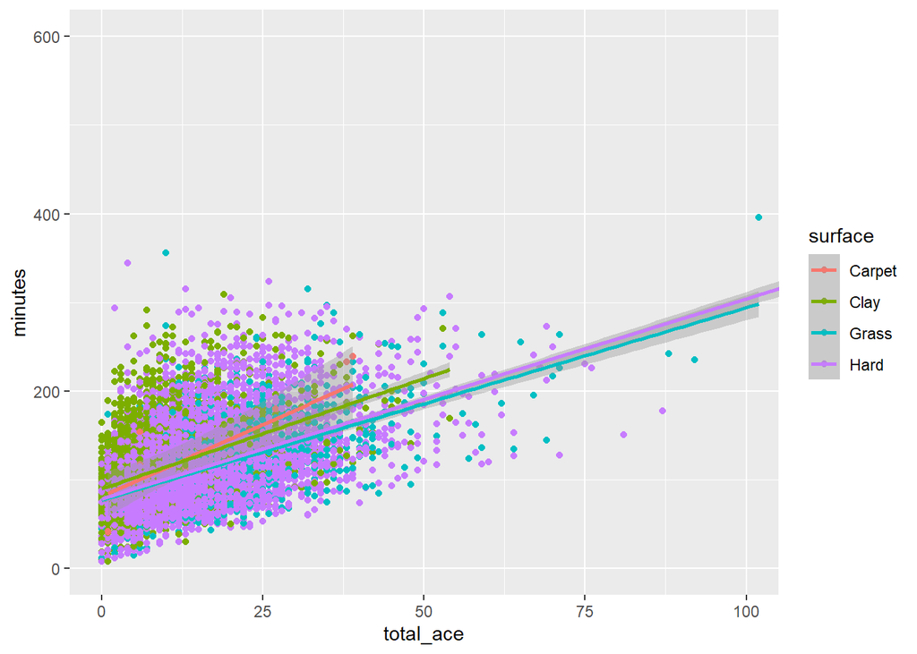

```r
ggplot(atp, aes(x=total_ace, y = minutes, color=surface))+
  geom_point()+
  geom_smooth(method = "lm")+
  coord_cartesian(xlim = c(NA, 100), ylim = c(NA, 600))
```

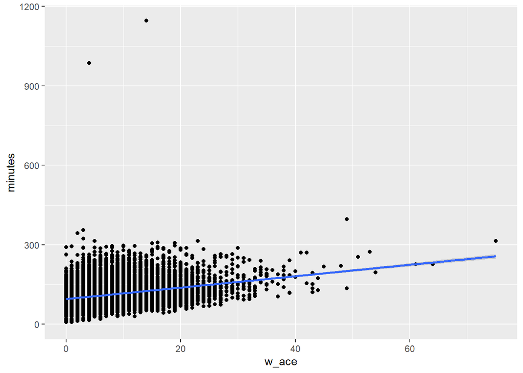

```r
ggplot(atp, aes(x=w_ace, y = minutes))+
  geom_point()+
  geom_smooth(method = 'lm')
```

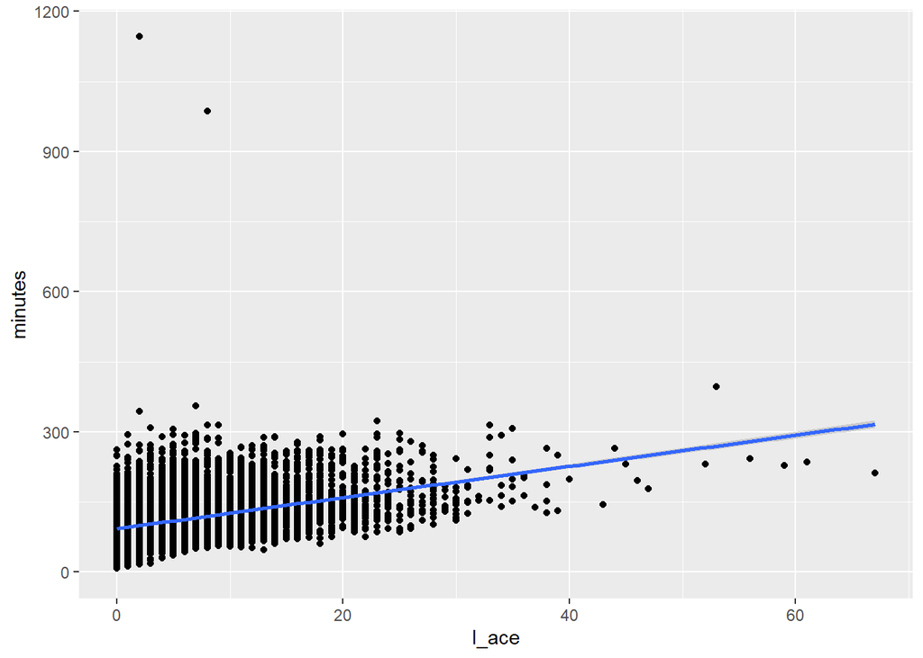

```r
ggplot(atp, aes(x=l_ace, y = minutes))+
  geom_point()+
  geom_smooth(method = 'lm')
```

# Orator: Brian Surless

### Q1: How does the distribution for match durations differ between different major tournaments?

Here we are able to see that the WTA and ATP have a few of the same popular tournaments but also some that aren’t applicable for the ATP. I found it interesting that the ATP had a higher match duration on average across different tournaments. I also found it interesting that Dubai had a lower average match duration in relation to the other tournaments in the ATP.

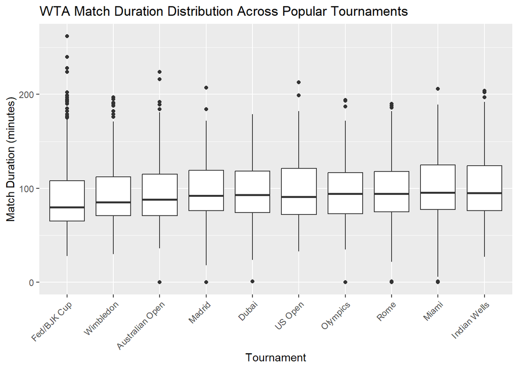

```r
duration_WTA = WTA %>%
  mutate(tourney_name2 = ifelse(str_detect(tourney_name, "Fed Cup|BJK Cup"), "Fed/BJK Cup", tourney_name)) %>%
  mutate(tourney_name2 = str_replace_all(tourney_name2, "US open", "US Open")) %>%
  filter(tourney_name2 %in% c("Australian Open", "Wimbledon", "US Open", "Indian Wells", "Miami", "Rome", "Olympics", "Dubai", "Madrid", "Fed/BJK Cup")) %>%
  filter(minutes < 275)

ggplot(data = duration_WTA, aes(x = reorder(tourney_name2, minutes), y = minutes)) +
  geom_boxplot() +
  labs(title = "WTA Match Duration Distribution Across Popular Tournaments",
       x = "Tournament",
       y = "Match Duration (minutes)") +
  theme(axis.text.x = element_text(angle = 45, hjust = 1))
```

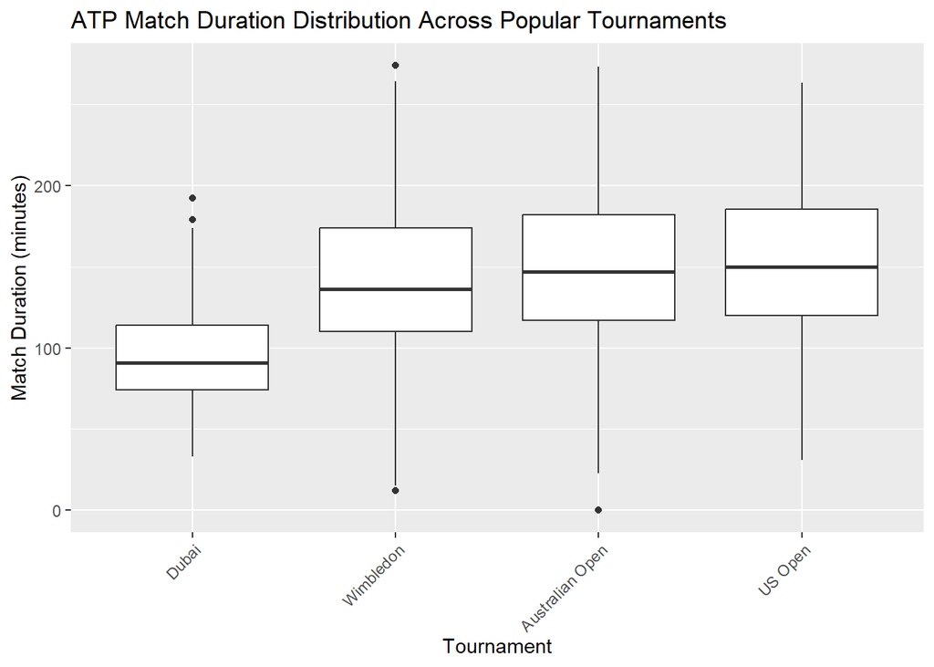

```r
duration_ATP = ATP %>%
  mutate(tourney_name2 = ifelse(str_detect(tourney_name, "Fed Cup|BJK Cup"), "Fed/BJK Cup", tourney_name)) %>%
  mutate(tourney_name2 = str_replace_all(tourney_name2, "US open", "US Open")) %>%
  filter(tourney_name2 %in% c("Australian Open", "Wimbledon", "US Open", "Indian Wells", "Miami", "Rome", "Olympics", "Dubai", "Madrid", "Fed/BJK Cup")) %>%
  filter(minutes < 275)

ggplot(data = duration_ATP, aes(x = reorder(tourney_name2, minutes), y = minutes)) +
  geom_boxplot() +
  labs(title = "ATP Match Duration Distribution Across Popular Tournaments",
       x = "Tournament",
       y = "Match Duration (minutes)") +
  theme(axis.text.x = element_text(angle = 45, hjust = 1))
```

### Q2: Is there a relationship for how players from different countries perform on different surfaces?

This question can help us explore whether or not players from different countries have an advantage in matches on specific surfaces, giving further insight into strategy. Here it is clear to see that the USA is leading for both wins and losses for most of the matches per each surface. One factor that isn’t illustrated in these visualizations is the win percentages for each country which means that there may be potential biases for certain countries who have had more overall matches than other countries. This may explain why the USA is leading in most of these count and proportion based charts. This leads me curious to learn more about the win percentage for each individual country on each surface. This win percentage data could then be used to factor into match result predictability if there is a trend of a specific country performing better overall on a specific surface than their opponent.

```r
prop_winners_WTA = WTA %>%
  group_by(winner_ioc, surface) %>%
  summarize(count = n()) %>%
  group_by(surface) %>%
  mutate(proportion = count / sum(count)) %>%
  top_n(10, wt = count) %>%
  ungroup()
```

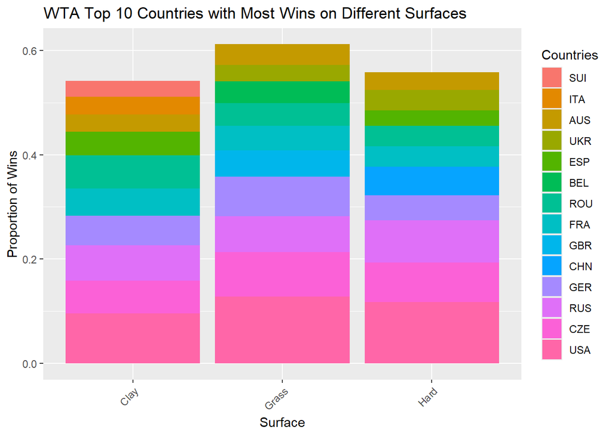

```r
ggplot(prop_winners_WTA, aes(x = surface, y = proportion, fill = fct_reorder(winner_ioc, proportion))) +
  geom_bar(stat = "identity") +
  labs(title = "WTA Top 10 Countries with Most Wins on Different Surfaces",
       x = "Surface",
       y = "Proportion of Wins") +
  theme(axis.text.x = element_text(angle = 45, hjust = 1)) +
  guides(fill = guide_legend(title = "Countries"))
```

```r
prop_winners_ATP = ATP %>%
  group_by(winner_ioc, surface) %>%
  summarize(count = n()) %>%
  group_by(surface) %>%
  mutate(proportion = count / sum(count)) %>%
  top_n(10, wt = count) %>%
  ungroup()
```

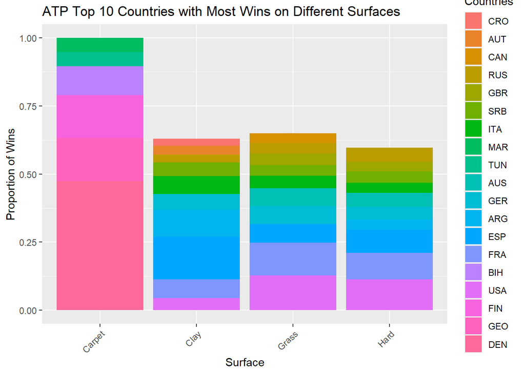

```r
ggplot(prop_winners_ATP, aes(x = surface, y = proportion, fill = fct_reorder(winner_ioc, proportion))) +
  geom_bar(stat = "identity") +
  labs(title = "ATP Top 10 Countries with Most Wins on Different Surfaces",
       x = "Surface",
       y = "Proportion of Wins") +
  theme(axis.text.x = element_text(angle = 45, hjust = 1)) +
  guides(fill = guide_legend(title = "Countries"))
```

```r
freq_winners_WTA = WTA %>%
  group_by(winner_ioc, surface) %>%
  summarize(count = n()) %>%
  group_by(surface) %>%
  top_n(10, wt = count) %>%
  ungroup()
```

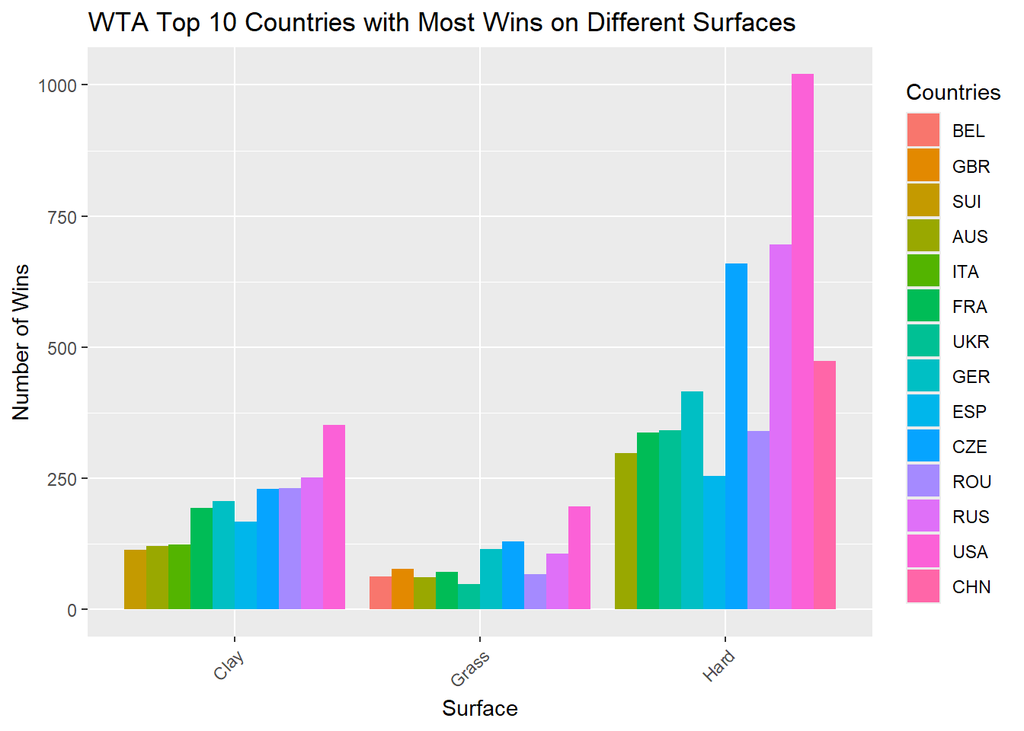

```r
ggplot(freq_winners_WTA, aes(x = surface, y = count, fill = fct_reorder(winner_ioc, count))) +
  geom_bar(stat = "identity", position = "dodge") +
  labs(title = "WTA Top 10 Countries with Most Wins on Different Surfaces",
       x = "Surface",
       y = "Number of Wins") +
  theme(axis.text.x = element_text(angle = 45, hjust = 1)) +
  guides(fill = guide_legend(title = "Countries"))
```

```r
freq_winners_ATP = ATP %>%
  group_by(winner_ioc, surface) %>%
  summarize(count = n()) %>%
  group_by(surface) %>%
  top_n(10, wt = count) %>%
  ungroup()
```

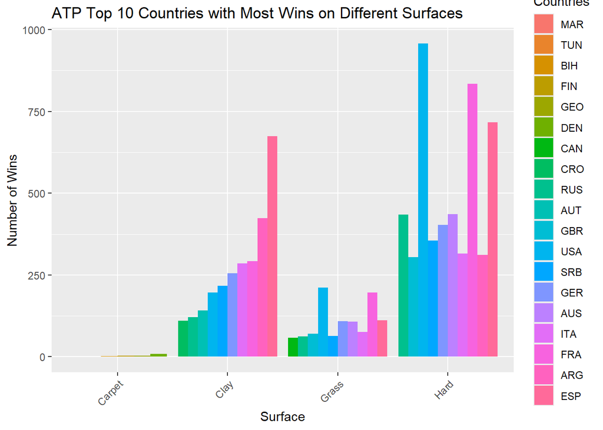

```r
ggplot(freq_winners_ATP, aes(x = surface, y = count, fill = fct_reorder(winner_ioc, count))) +
  geom_bar(stat = "identity", position = "dodge") +
  labs(title = "ATP Top 10 Countries with Most Wins on Different Surfaces",
       x = "Surface",
       y = "Number of Wins") +
  theme(axis.text.x = element_text(angle = 45, hjust = 1)) +
  guides(fill = guide_legend(title = "Countries"))
```

```r
prop_loser_WTA = WTA %>%
  group_by(loser_ioc, surface) %>%
  summarize(count = n()) %>%
  group_by(surface) %>%
  mutate(proportion = count / sum(count)) %>%
  top_n(10, wt = count) %>%
  ungroup()
```

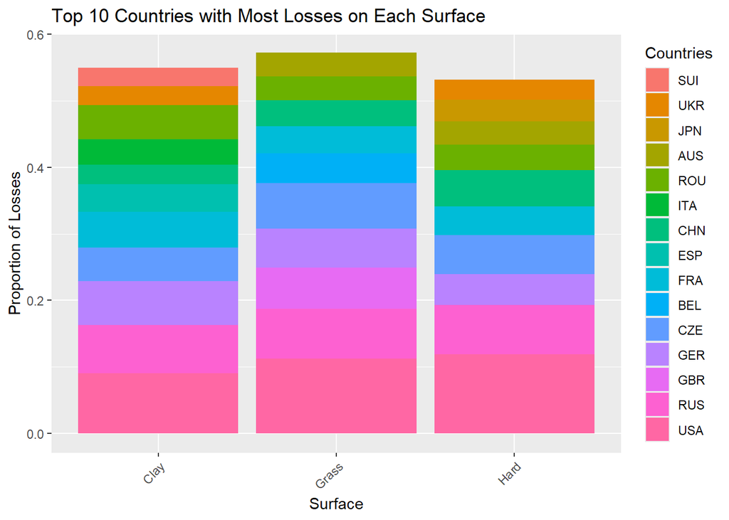

```r
ggplot(prop_loser_WTA, aes(x = surface, y = proportion, fill = fct_reorder(loser_ioc, proportion))) +
  geom_bar(stat = "identity") +
  labs(title = "Top 10 Countries with Most Losses on Each Surface",
       x = "Surface",
       y = "Proportion of Losses",
       colour = "Country") +
  theme(axis.text.x = element_text(angle = 45, hjust = 1)) +
  guides(fill = guide_legend(title = "Countries"))
```

```r
prop_loser_ATP = ATP %>%
  group_by(loser_ioc, surface) %>%
  summarize(count = n()) %>%
  group_by(surface) %>%
  mutate(proportion = count / sum(count)) %>%
  top_n(10, wt = count) %>%
  ungroup()
```

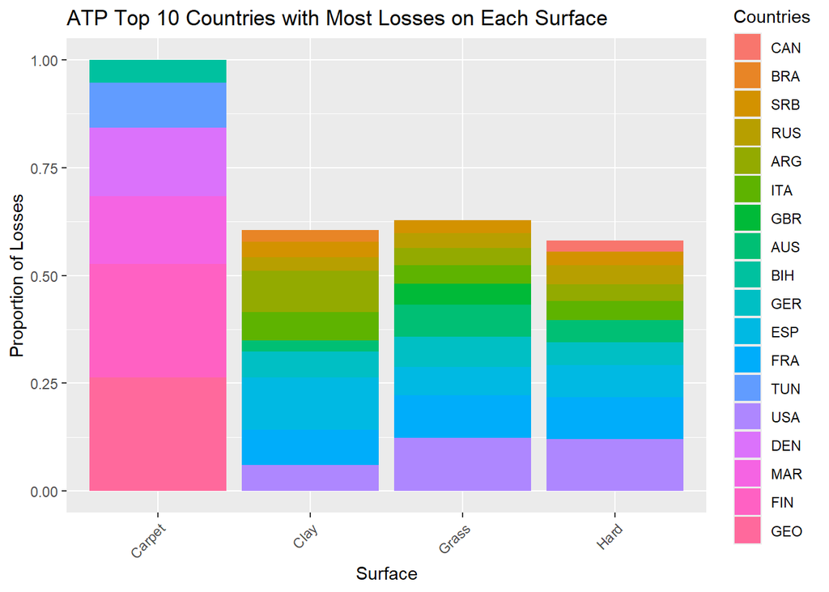

```r
ggplot(prop_loser_ATP, aes(x = surface, y = proportion, fill = fct_reorder(loser_ioc, proportion))) +
  geom_bar(stat = "identity") +
  labs(title = "ATP Top 10 Countries with Most Losses on Each Surface",
       x = "Surface",
       y = "Proportion of Losses",
       colour = "Country") +
  theme(axis.text.x = element_text(angle = 45, hjust = 1)) +
  guides(fill = guide_legend(title = "Countries"))
```

```r
freq_losers_WTA = WTA %>%
  group_by(loser_ioc, surface) %>%
  summarize(count = n()) %>%
  group_by(surface) %>%
  top_n(10, wt = count) %>%
  ungroup()
```

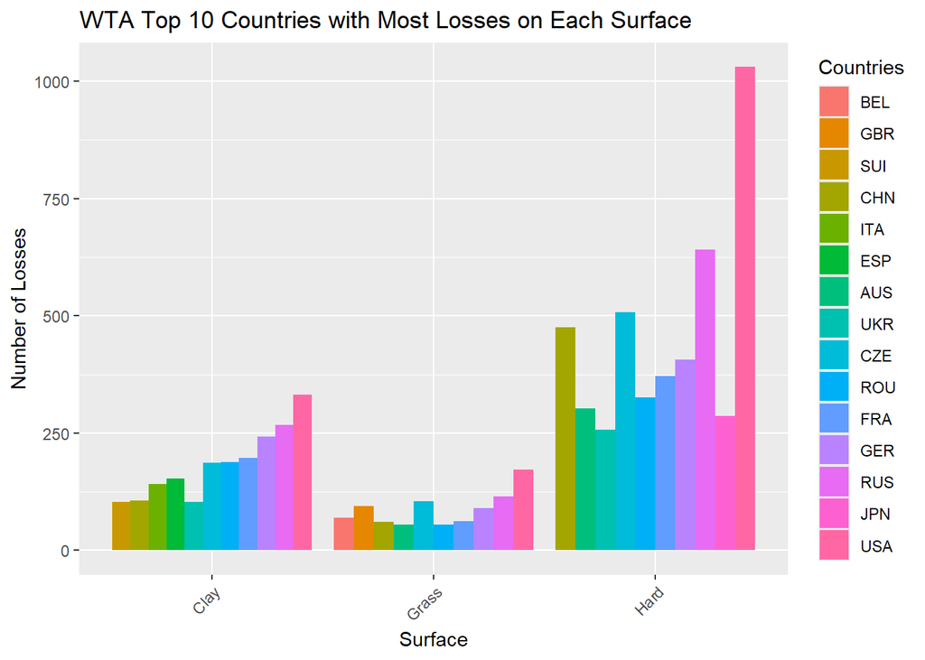

```r
ggplot(freq_losers_WTA, aes(x = surface, y = count, fill = fct_reorder(loser_ioc, count))) +
  geom_bar(stat = "identity", position = "dodge") +
  labs(title = "WTA Top 10 Countries with Most Losses on Each Surface",
       x = "Surface",
       y = "Number of Losses",
       colour = "Country") +
  theme(axis.text.x = element_text(angle = 45, hjust = 1)) +
  guides(fill = guide_legend(title = "Countries"))
```

```r
freq_losers_ATP = ATP %>%
  group_by(loser_ioc, surface) %>%
  summarize(count = n()) %>%
  group_by(surface) %>%
  top_n(10, wt = count) %>%
  ungroup()
```

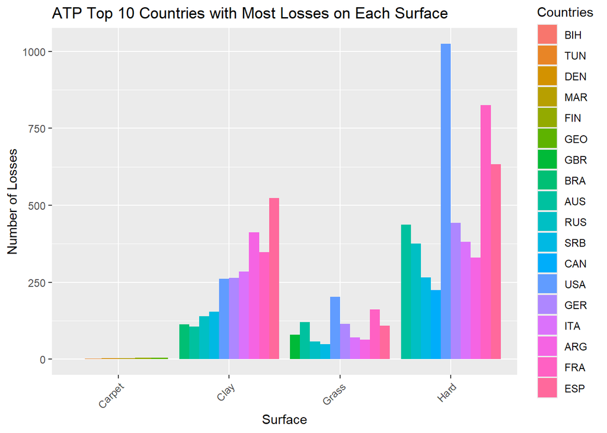

```r
ggplot(freq_losers_ATP, aes(x = surface, y = count, fill = fct_reorder(loser_ioc, count))) +
  geom_bar(stat = "identity", position = "dodge") +
  labs(title = "ATP Top 10 Countries with Most Losses on Each Surface",
       x = "Surface",
       y = "Number of Losses",
       colour = "Country") +
  theme(axis.text.x = element_text(angle = 45, hjust = 1)) +
  guides(fill = guide_legend(title = "Countries"))
```